# STAT 213 Review Solutions

Preliminary Code:

```r
library(tidyverse)
library(here)
library(broom)
theme_set(theme_minimal())

titanic_df <- read_csv(here("data/titanic.csv"),
                       col_types = list(Pclass = col_factor())) |>
  mutate(Pclass = fct_recode(Pclass,
                             "1st" = "1",
                             "2nd" = "2",
                             "3rd" = "3"))
titanic_df
```

**Exercise 1**. Fit a logistic regression model with `Fare` as a predictor. Obtain summary output with `tidy()` and use `ggplot2` to construct a plot of the model.

```r
fare_mod <- glm(Survived ~ Fare, data = titanic_df, family = "binomial")
fare_mod |> tidy()
```

```
# A tibble: 2 × 5
  term        estimate std.error statistic  p.value
  <chr>          <dbl>     <dbl>     <dbl>    <dbl>
1 (Intercept)  -0.941    0.0951      -9.90 4.36e-23
2 Fare          0.0152   0.00223      6.81 9.79e-12
```

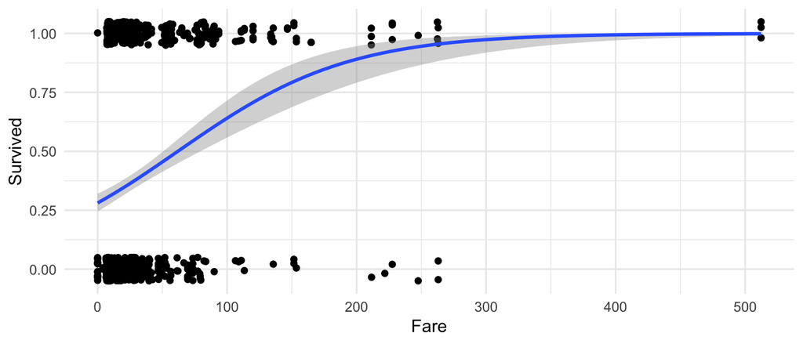

```r
ggplot(data = titanic_df, aes(x = Fare, y = Survived)) +
  geom_jitter(height = 0.05) +
  geom_smooth(method = "glm", method.args = list(family = "binomial")) +
  theme_minimal()
```

**Exercise 2**. Fit a logistic regression model with `Sex` as the predictor. Make an attempt at interpreting the resulting fitted coefficient for `Sex` on either the log-odds scale or the odds scale (keeping in mind that `Sex` is categorical so your interpretation should be comparing odds of survival of female and male passengers).

```r
sex_mod <- glm(Survived ~ Sex, data = titanic_df, family = "binomial")
sex_mod |> tidy()
```

```
# A tibble: 2 × 5
  term        estimate std.error statistic  p.value
  <chr>          <dbl>     <dbl>     <dbl>    <dbl>
1 (Intercept)     1.06     0.129      8.19 2.58e-16
2 Sexmale        -2.51     0.167    -15.0  4.26e-51
```

```r
exp(-2.51)
```

```
[1] 0.08126824
```

The model predicts that the log-odds of survival on the titanic for males are 2.51 units less than the log-odds of survival on the titanic for females.

Or, the model predicts that the odds of male survival on the titanic is 0.081 times the odds of female survival on the titanic.

Neither interpretation is particularly useful for an intuitive understanding of the difference in probability that a male survives compared to the probability that a female survives.